# Analysis NASA-TLX subscales

## Load packages and data

```r
library(WRS2)
library(rcompanion)
library(feather)
library(ggplot2)
library(plyr)
library(ez)
library(schoRsch)
library(MASS)
library(car)
library(tidyverse)
library(rstatix)
```

```r
# df_nasa has four rows per particpant, one for each nasa-tlx test
df_nasa <- read_feather(path = 'C:/Users/janin/Desktop/Studium/Masterarbeit/09_results_files/results_test_18-03-2020_messwdh_nasa.file')
```

```
Coercing int64 to doubleCoercing int64 to doubleCoercing int64 to doubleCoercing int64 to double
```

## Prepare the data

Assign participants to the experimental groups:

- version 1 and 2 –> control group
- version 3 und 4 –> experimental group context free
- version 5 und 6–> experimental group context sensitive

```r
df_nasa$group <- ifelse((df_nasa$version == 5 | df_nasa$version == 6), 'context-sensitive experimental group', ifelse((df_nasa$version == 1 | df_nasa$version == 2), 'control group', 'context-free experimental group'))
```

Convert trial, group and subject number to factors

```r
df_nasa$trial <- factor(df_nasa$trial, levels=c(0,1,2,3), labels=c('0','1','2','3'))
df_nasa$group <- factor(df_nasa$group)
df_nasa$partnr <- factor(df_nasa$partnr)
```

### Descriptive statistics

```r
df_nasa %>%
  group_by(trial, group) %>%
  summarise(mean(NASATLX), sd(NASATLX))
```

| mean(NASATLX) | sd(NASATLX) |
| --- | --- |
| 4.328788 | 1.038322 |

```r
df_nasa %>%
  group_by(trial, group) %>%
  summarise(mean(nasa_tlx_effort), sd(nasa_tlx_effort))
```

| mean(nasa_tlx_effort) | sd(nasa_tlx_effort) |
| --- | --- |
| 4.495455 | 1.294519 |

```r
df_nasa %>%
  group_by(trial, group) %>%
  summarise(mean(nasa_tlx_frustration), sd(nasa_tlx_frustration))
```

| mean(nasa_tlx_frustration) | sd(nasa_tlx_frustration) |
| --- | --- |
| 4.422727 | 1.722383 |

```r
df_nasa %>%
  group_by(trial, group) %>%
  summarise(mean(nasa_tlx_mental_demand), sd(nasa_tlx_mental_demand))
```

| mean(nasa_tlx_mental_demand) | sd(nasa_tlx_mental_demand) |
| --- | --- |
| 4.918182 | 1.365804 |

```r
df_nasa %>%
  group_by(trial, group) %>%
  summarise(mean(nasa_tlx_performance), sd(nasa_tlx_performance))
```

| mean(nasa_tlx_performance) | sd(nasa_tlx_performance) |
| --- | --- |
| 4.4 | 1.434729 |

```r
df_nasa %>%
  group_by(trial, group) %>%
  summarise(mean(nasa_tlx_physical_demand), sd(nasa_tlx_physical_demand))
```

| mean(nasa_tlx_physical_demand) | sd(nasa_tlx_physical_demand) |
| --- | --- |
| 2.709091 | 1.687155 |

```r
df_nasa %>%
  group_by(trial, group) %>%
  summarise(mean(nasa_tlx_time), sd(nasa_tlx_time))
```

| mean(nasa_tlx_time) | sd(nasa_tlx_time) |
| --- | --- |
| 5.027273 | 1.426808 |

## Analyse the subscales

### Effort subscale

Robust ANOVA yields no significant results.

```r
nasa_effort_anova <- ezANOVA(
  data=df_nasa
  , dv = nasa_tlx_effort
  , wid = partnr
  , within = trial
  , between = group
  , detailed = TRUE
  , return_aov = TRUE
  , type = 3)
```

```
Data is unbalanced (unequal N per group). Make sure you specified a well-considered value for the type argument to ezANOVA().
```

```r
anova_out(nasa_effort_anova)
```

```
$`--- ANOVA RESULTS     ------------------------------------`
       Effect       MSE df1 df2      F     p petasq getasq
1 (Intercept) 4.7641941   1  52 887.23 0.000   0.94   0.92
2       group 4.7641941   2  52   0.11 0.900   0.00   0.00
3       trial 0.6891965   3 156   1.95 0.124   0.04   0.01
4 group:trial 0.6891965   6 156   1.61 0.148   0.06   0.02

$`--- SPHERICITY TESTS  ------------------------------------`
       Effect p_Mauchly GGEpsilon  p_GG HFEpsilon  p_HF
1       trial     0.125     0.892 0.131     0.945 0.127
2 group:trial     0.125     0.892 0.157     0.945 0.153

$`--- FORMATTED RESULTS ------------------------------------`
       Effect                                    Text
1 (Intercept)  F(1, 52) = 887.23, p < .001, np2 = .94
2       group  F(2, 52) =   0.11, p = .900, np2 < .01
3       trial F(3, 156) =   1.95, p = .124, np2 = .04
4 group:trial F(6, 156) =   1.61, p = .148, np2 = .06

$`NOTE:`
[1] "No adjustments necessary (all p_Mauchly > 0.05)."
```

Plot the interaction

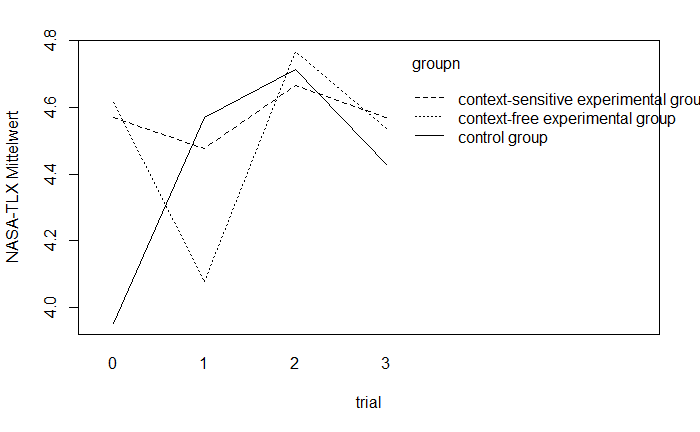

```r
interaction.plot(df_nasa$`trial`, df_nasa$group, df_nasa$nasa_tlx_effort, xlab = 'trial', ylab = 'NASA-TLX Mittelwert', trace.label = 'groupn', cex=1.3, pch=1, pt.cex = 1)
```

Check normal distribution assumption by plotting residuals and run Shapiro-Wilk test.

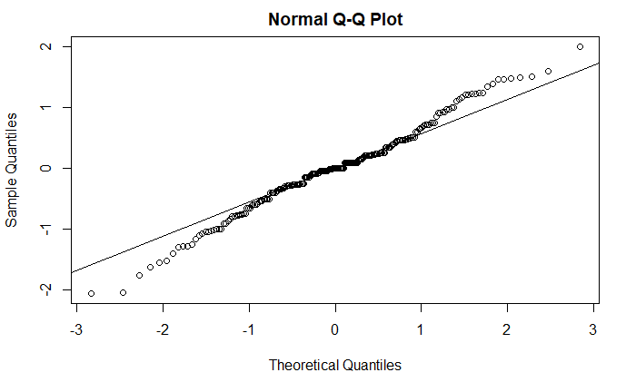

```r
nasa_effort.pr <- proj(nasa_effort_anova$aov)
effort_res <- nasa_effort.pr[[3]][, "Residuals"]
qqnorm(effort_res); qqline(effort_res)
```

```r
# Run Shapiro-Wilk test
shapiro.test(x = effort_res )
```

```
    Shapiro-Wilk normality test

data:  effort_res
W = 0.98833, p-value = 0.07026
```

Check variance homogenity assumption through Levene test for homogenity of variance across groups.

```r
leveneTest(df_nasa$nasa_tlx_effort~df_nasa$group)
```

```
Levene's Test for Homogeneity of Variance (center = median)
       Df F value Pr(>F)
group   2   1.091 0.3377
      217
```

QQplot of the residuals indicates that the assumption of normal distribution is not met, so we compute robust ANOVA (n.s.).

```r
bwtrim(formula = nasa_tlx_effort ~ group * trial, id = partnr, data = df_nasa)
```

```
Call:
bwtrim(formula = nasa_tlx_effort ~ group * trial, id = partnr,
    data = df_nasa)
```

|  | value | df1 | df2 | p.value |
| --- | --- | --- | --- | --- |
| group | 0.2982 | 2 | 15.9336 | 0.7462 |
| trial | 1.7036 | 3 | 19.0012 | 0.2001 |
| group:trial | 1.5933 | 6 | 15.8285 | 0.2135 |

```
NA
```

### Frustration subscale

Robust ANOVA shows a significant effect of trial. Post-hoc comparisons between trial 0/1 versus 2/3 are all significant. This indicates that frustration is higher in the last two trials in comparison to the first two trials.

```r
nasa_frustration_anova <- ezANOVA(
  data=df_nasa
  , dv = nasa_tlx_frustration
  , wid = partnr
  , within = trial
  , between = group
  , detailed = TRUE
  , return_aov = TRUE
  , type = 3)
```

```
Data is unbalanced (unequal N per group). Make sure you specified a well-considered value for the type argument to ezANOVA().
```

```r
anova_out(nasa_frustration_anova)
```

```
$`--- ANOVA RESULTS     ------------------------------------`
       Effect      MSE df1 df2      F     p petasq getasq
1 (Intercept) 8.193223   1  52 508.65 0.000   0.91   0.87
2       group 8.193223   2  52   0.97 0.386   0.04   0.03
3       trial 1.098079   3 156   8.34 0.000   0.14   0.04
4 group:trial 1.098079   6 156   1.54 0.169   0.06   0.02

$`--- SPHERICITY TESTS  ------------------------------------`
       Effect p_Mauchly GGEpsilon  p_GG HFEpsilon  p_HF
1       trial     0.000     0.808 0.000     0.850 0.000
2 group:trial     0.000     0.808 0.184     0.850 0.180

$`--- FORMATTED RESULTS ------------------------------------`
       Effect                                    Text
1 (Intercept)  F(1, 52) = 508.65, p < .001, np2 = .91
2       group  F(2, 52) =   0.97, p = .386, np2 = .04
3       trial F(3, 156) =   8.34, p < .001, np2 = .14
4 group:trial F(6, 156) =   1.54, p = .184, np2 = .06

$`NOTE:`
[1] "p-values for the following effects were GG-adjusted (p_Mauchly <= 0.05): trial; group:trial. Reporting uncorrected degrees of freedom."
```

Plot the interaction

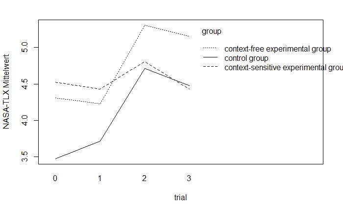

```r
interaction.plot(df_nasa$`trial`, df_nasa$group, df_nasa$nasa_tlx_frustration, xlab = 'trial', ylab = 'NASA-TLX Mittelwert', trace.label = 'group', cex=1.3, pch=1, pt.cex = 1)
```

Check normal distribution assumption by plotting residuals and run Shapiro-Wilk test.

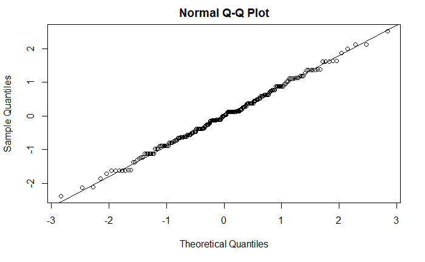

```r
nasa_frustration.pr <- proj(nasa_frustration_anova$aov)
frustration_res <- nasa_frustration.pr[[3]][, "Residuals"]
qqnorm(frustration_res); qqline(frustration_res)
```

```r
# Run Shapiro-Wilk test
shapiro.test(x = frustration_res )
```

```
    Shapiro-Wilk normality test

data:  frustration_res
W = 0.99659, p-value = 0.9151
```

QQplot of the residuals indicates that the assumption of normal distribution is met.

Check variance homogenity assumption through Levene test for homogenity of variance across groups.

```r
leveneTest(df_nasa$nasa_tlx_frustration~df_nasa$group)
```

```
Levene's Test for Homogeneity of Variance (center = median)
       Df F value  Pr(>F)
group   2   3.888 0.02193 *
      217
---
Signif. codes:  0 ‘***’ 0.001 ‘**’ 0.01 ‘*’ 0.05 ‘.’ 0.1 ‘ ’ 1
```

```r
bwtrim(formula = nasa_tlx_frustration ~ group * trial, id = partnr, data = df_nasa)
```

```
Call:
bwtrim(formula = nasa_tlx_frustration ~ group * trial, id = partnr,
    data = df_nasa)
```

|  | value | df1 | df2 | p.value |
| --- | --- | --- | --- | --- |
| group | 1.0298 | 2 | 15.7020 | 0.3800 |
| trial | 5.6301 | 3 | 18.2830 | 0.0065 |
| group:trial | 0.8993 | 6 | 15.4507 | 0.5198 |

```
NA
```

##### Post-hoc tests

```r
pwc_trial <- df_nasa %>%
  wilcox_test(nasa_tlx_frustration ~ trial,
              comparisons = list(c(0,2), c(0,3), c(1,2), c(1,3) ),
              paired = TRUE, p.adjust.method = "holm")
pwc_trial
```

|  | .y. | group1 | group2 | n1 | n2 | statistic | p | p.adj | p.adj.signif |
| --- | --- | --- | --- | --- | --- | --- | --- | --- | --- |
| 1 | nasa_tlx_frustration | 0 | 2 | 55 | 55 | 181.0 | 2.00e-03 | 0.006000 | ** |
| 2 | nasa_tlx_frustration | 0 | 3 | 55 | 55 | 202.5 | 1.40e-02 | 0.027000 | * |
| 3 | nasa_tlx_frustration | 1 | 2 | 55 | 55 | 63.0 | 3.87e-05 | 0.000155 | *** |
| 4 | nasa_tlx_frustration | 1 | 3 | 55 | 55 | 162.5 | 1.90e-02 | 0.027000 | * |

### Physical demand subscale

Robust ANOVA shows a significant effect of trial. Post-hoc comparisons between trial 0 versus 1/2/3 and 1 versus 3 are all significant. This indicates that physical demand increases over trials.

```r
nasa_physical_demand_anova <- ezANOVA(
  data = df_nasa,
  dv = nasa_tlx_physical_demand,
  wid = partnr,
  within = trial,
  between = group,
  detailed = TRUE,
  return_aov = TRUE,
  type = 3

)
```

```
Data is unbalanced (unequal N per group). Make sure you specified a well-considered value for the type argument to ezANOVA().
```

```r
anova_out(nasa_physical_demand_anova)
```

```
$`--- ANOVA RESULTS     ------------------------------------`
       Effect       MSE df1 df2      F     p petasq getasq
1 (Intercept) 8.2440124   1  52 180.21 0.000   0.78   0.72
2       group 8.2440124   2  52   1.83 0.170   0.07   0.05
3       trial 0.8815629   3 156   9.21 0.000   0.15   0.04
4 group:trial 0.8815629   6 156   0.21 0.973   0.01   0.00

$`--- SPHERICITY TESTS  ------------------------------------`
       Effect p_Mauchly GGEpsilon  p_GG HFEpsilon  p_HF
1       trial     0.010     0.821 0.000     0.865 0.000
2 group:trial     0.010     0.821 0.955     0.865 0.961

$`--- FORMATTED RESULTS ------------------------------------`
       Effect                                    Text
1 (Intercept)  F(1, 52) = 180.21, p < .001, np2 = .78
2       group  F(2, 52) =   1.83, p = .170, np2 = .07
3       trial F(3, 156) =   9.21, p < .001, np2 = .15
4 group:trial F(6, 156) =   0.21, p = .955, np2 = .01

$`NOTE:`
[1] "p-values for the following effects were GG-adjusted (p_Mauchly <= 0.05): trial; group:trial. Reporting uncorrected degrees of freedom."
```

Interaction plot

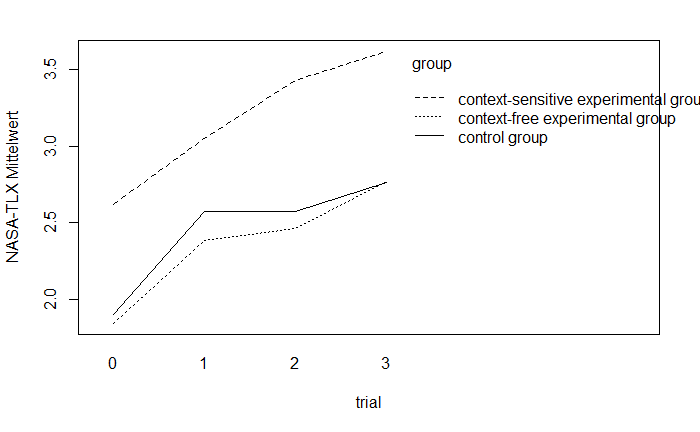

```r
interaction.plot(df_nasa$`trial`, df_nasa$group, df_nasa$nasa_tlx_physical_demand, xlab = 'trial', ylab = 'NASA-TLX Mittelwert', trace.label = 'group', cex=1.3, pch=1, pt.cex = 1)
```

Check normal distribution assumption by plotting residuals and compute Shapiro-Wilk test

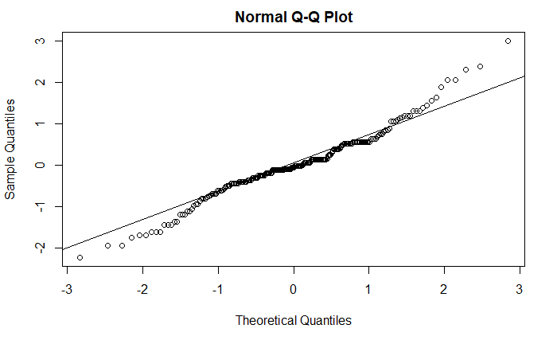

```r
nasa_physical_demand.pr <- proj(nasa_physical_demand_anova$aov)
physical_demand_res <- nasa_physical_demand.pr[[3]][, "Residuals"]
qqnorm(physical_demand_res); qqline(physical_demand_res)
```

```r
# Run Shapiro-Wilk test
shapiro.test(x = physical_demand_res )
```

```
    Shapiro-Wilk normality test

data:  physical_demand_res
W = 0.97043, p-value = 0.0001452
```

Run Levene test for homogeneity of variance across groups

```r
leveneTest(df_nasa$nasa_tlx_physical_demand~df_nasa$group)
```

```
Levene's Test for Homogeneity of Variance (center = median)
       Df F value  Pr(>F)
group   2  3.6104 0.02868 *
      217
---
Signif. codes:  0 ‘***’ 0.001 ‘**’ 0.01 ‘*’ 0.05 ‘.’ 0.1 ‘ ’ 1
```

QQplot of the residuals indicates that the assumption of normal distribution is not met and significant Levene test indicates that homogeneity of variance is not given, so we compute robust ANOVA.

```r
bwtrim(formula = nasa_tlx_physical_demand ~ group * trial, id = partnr, data = df_nasa)
```

```
Call:
bwtrim(formula = nasa_tlx_physical_demand ~ group * trial, id = partnr,
    data = df_nasa)
```

|  | value | df1 | df2 | p.value |
| --- | --- | --- | --- | --- |
| group | 1.0795 | 2 | 15.6595 | 0.3638 |
| trial | 4.6226 | 3 | 17.1491 | 0.0152 |
| group:trial | 0.4005 | 6 | 15.2717 | 0.8675 |

```
NA
```

Post-hoc tests

```r
pwc_trial <- df_nasa %>%
  wilcox_test(nasa_tlx_physical_demand ~ trial,
              comparisons = list(c(0,1), c(0,2), c(0,3),  c(1,3) ),
              paired = TRUE, p.adjust.method = "holm")
pwc_trial
```

|  | .y. | group1 | group2 | n1 | n2 | statistic | p | p.adj | p.adj.signif |
| --- | --- | --- | --- | --- | --- | --- | --- | --- | --- |
| 1 | nasa_tlx_physical_demand | 0 | 1 | 55 | 55 | 74.5 | 5.00e-03 | 0.011000 | * |
| 2 | nasa_tlx_physical_demand | 0 | 2 | 55 | 55 | 80.0 | 1.00e-03 | 0.004000 | ** |
| 3 | nasa_tlx_physical_demand | 0 | 3 | 55 | 55 | 48.0 | 7.16e-05 | 0.000286 | *** |
| 4 | nasa_tlx_physical_demand | 1 | 3 | 55 | 55 | 70.0 | 2.00e-02 | 0.020000 | * |

### Time subscale

Robust ANOVA shows a significant effect of trial. Post-hoc comparisons between trial 0 versus 1/2/3 and 1 versus 2 are all significant. This indicates that time pressure increases over trials.

```r
nasa_time_anova <- ezANOVA(
  data = df_nasa,
  dv = nasa_tlx_time,
  wid = partnr,
  within = trial,
  between = group,
  detailed = TRUE,
  return_aov = TRUE,
  type = 3

)
```

```
Data is unbalanced (unequal N per group). Make sure you specified a well-considered value for the type argument to ezANOVA().
```

```r
anova_out(nasa_time_anova)
```

```
$`--- ANOVA RESULTS     ------------------------------------`
       Effect       MSE df1 df2      F     p petasq getasq
1 (Intercept) 5.5523387   1  52 943.13 0.000   0.95   0.93
2       group 5.5523387   2  52   0.42 0.662   0.02   0.01
3       trial 0.6939279   3 156  19.53 0.000   0.27   0.09
4 group:trial 0.6939279   6 156   1.47 0.192   0.05   0.02

$`--- SPHERICITY TESTS  ------------------------------------`
       Effect p_Mauchly GGEpsilon  p_GG HFEpsilon  p_HF
1       trial     0.000     0.762 0.000     0.799 0.000
2 group:trial     0.000     0.762 0.209     0.799 0.207

$`--- FORMATTED RESULTS ------------------------------------`
       Effect                                    Text
1 (Intercept)  F(1, 52) = 943.13, p < .001, np2 = .95
2       group  F(2, 52) =   0.42, p = .662, np2 = .02
3       trial F(3, 156) =  19.53, p < .001, np2 = .27
4 group:trial F(6, 156) =   1.47, p = .209, np2 = .05

$`NOTE:`
[1] "p-values for the following effects were GG-adjusted (p_Mauchly <= 0.05): trial; group:trial. Reporting uncorrected degrees of freedom."
```

Interaction plot

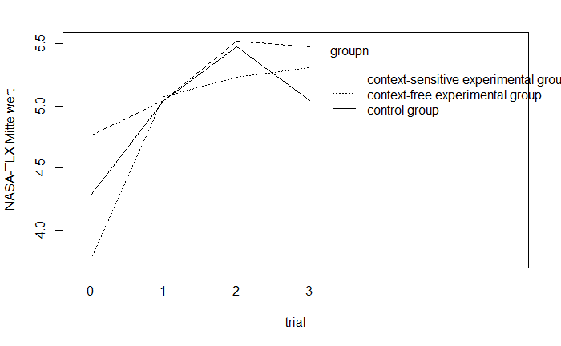

```r
interaction.plot(df_nasa$`trial`, df_nasa$group, df_nasa$nasa_tlx_time, xlab = 'trial', ylab = 'NASA-TLX Mittelwert', trace.label = 'groupn', cex=1.3, pch=1, pt.cex = 1)
```

Check normal distribution assumption by plotting residuals and running Shapiro-Wilk test

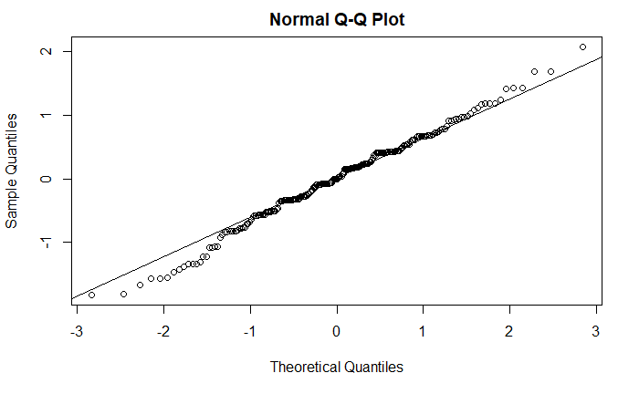

```r
nasa_time.pr <- proj(nasa_time_anova$aov)
time_res <- nasa_time.pr[[3]][, "Residuals"]
qqnorm(time_res); qqline(time_res)
```

```r
# Run Shapiro-Wilk test
shapiro.test(x = time_res )
```

```
    Shapiro-Wilk normality test

data:  time_res
W = 0.9924, p-value = 0.3142
```

QQplot of the residuals indicates that the assumption of normal distribution met

Run Levene test for homogeneity of variance across groups

```r
leveneTest(df_nasa$nasa_tlx_time~df_nasa$group)
```

```
Levene's Test for Homogeneity of Variance (center = median)
       Df F value  Pr(>F)
group   2  2.3757 0.09536 .
      217
---
Signif. codes:  0 ‘***’ 0.001 ‘**’ 0.01 ‘*’ 0.05 ‘.’ 0.1 ‘ ’ 1
```

```r
bwtrim(formula = nasa_tlx_time ~ group * trial, id = partnr, data = df_nasa)
```

```
Call:
bwtrim(formula = nasa_tlx_time ~ group * trial, id = partnr,
    data = df_nasa)
```

|  | value | df1 | df2 | p.value |
| --- | --- | --- | --- | --- |
| group | 0.5062 | 2 | 14.7704 | 0.6129 |
| trial | 6.6508 | 3 | 18.4806 | 0.0031 |
| group:trial | 0.8242 | 6 | 15.7114 | 0.5679 |

```
NA
```

Post-hoc tests

```r
pwc_trial <- df_nasa %>%
  wilcox_test(nasa_tlx_time ~ trial,
              comparisons = list(c(0,1), c(0,2), c(0,3), c(1,2)),
              paired = TRUE, p.adjust.method = "holm")
pwc_trial
```

|  | .y. | group1 | group2 | n1 | n2 | statistic | p | p.adj | p.adj.signif |
| --- | --- | --- | --- | --- | --- | --- | --- | --- | --- |
| 1 | nasa_tlx_time | 0 | 1 | 55 | 55 | 103 | 2.18e-04 | 4.36e-04 | *** |
| 2 | nasa_tlx_time | 0 | 2 | 55 | 55 | 85 | 9.55e-06 | 3.82e-05 | **** |
| 3 | nasa_tlx_time | 0 | 3 | 55 | 55 | 85 | 4.61e-05 | 1.38e-04 | *** |
| 4 | nasa_tlx_time | 1 | 2 | 55 | 55 | 120 | 4.00e-03 | 4.00e-03 | ** |

### Mental demand subscale

Robust ANOVA yields no significant effects.

```r
nasa_mental_demand_anova <- ezANOVA(
  data = df_nasa,
  dv = nasa_tlx_mental_demand,
  wid = partnr,
  within = trial,
  between = group,
  detailed = TRUE,
  return_aov = TRUE,
  type = 3

)
```

```
Data is unbalanced (unequal N per group). Make sure you specified a well-considered value for the type argument to ezANOVA().
```

```r
anova_out(nasa_mental_demand_anova)
```

```
$`--- ANOVA RESULTS     ------------------------------------`
       Effect       MSE df1 df2      F     p petasq getasq
1 (Intercept) 5.7848338   1  52 881.53 0.000   0.94   0.93
2       group 5.7848338   2  52   0.15 0.863   0.01   0.00
3       trial 0.6573331   3 156   0.65 0.585   0.01   0.00
4 group:trial 0.6573331   6 156   0.61 0.719   0.02   0.01

$`--- SPHERICITY TESTS  ------------------------------------`
       Effect p_Mauchly GGEpsilon  p_GG HFEpsilon  p_HF
1       trial     0.001     0.787 0.550     0.827 0.557
2 group:trial     0.001     0.787 0.680     0.827 0.688

$`--- FORMATTED RESULTS ------------------------------------`
       Effect                                    Text
1 (Intercept)  F(1, 52) = 881.53, p < .001, np2 = .94
2       group  F(2, 52) =   0.15, p = .863, np2 = .01
3       trial F(3, 156) =   0.65, p = .550, np2 = .01
4 group:trial F(6, 156) =   0.61, p = .680, np2 = .02

$`NOTE:`
[1] "p-values for the following effects were GG-adjusted (p_Mauchly <= 0.05): trial; group:trial. Reporting uncorrected degrees of freedom."
```

Interaction plot

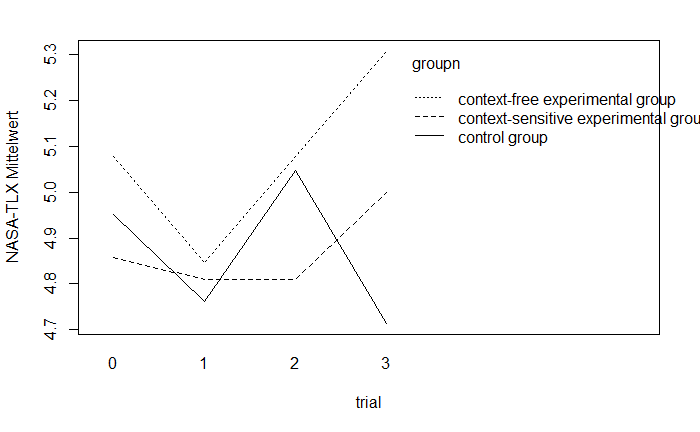

```r
interaction.plot(df_nasa$`trial`, df_nasa$group, df_nasa$nasa_tlx_mental_demand, xlab = 'trial', ylab = 'NASA-TLX Mittelwert', trace.label = 'groupn', cex=1.3, pch=1, pt.cex = 1)
```

Check normal distribution assumption by plotting residuals and running Shapiro-Wilk test

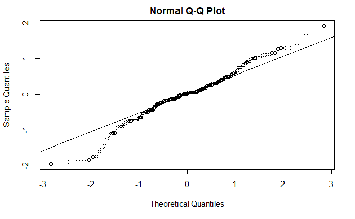

```r
nasa_mental_demand.pr <- proj(nasa_mental_demand_anova$aov)
mental_demand_res <- nasa_mental_demand.pr[[3]][, "Residuals"]
qqnorm(mental_demand_res); qqline(mental_demand_res)
```

```r
# Run Shapiro-Wilk test
shapiro.test(x = mental_demand_res )
```

```
    Shapiro-Wilk normality test

data:  mental_demand_res
W = 0.97748, p-value = 0.001376
```

Run Levene test for homogeneity of variance across groups.

```r
leveneTest(df_nasa$nasa_tlx_mental_demand~df_nasa$group)
```

```
Levene's Test for Homogeneity of Variance (center = median)
       Df F value  Pr(>F)
group   2   2.796 0.06325 .
      217
---
Signif. codes:  0 ‘***’ 0.001 ‘**’ 0.01 ‘*’ 0.05 ‘.’ 0.1 ‘ ’ 1
```

```r
bwtrim(formula = nasa_tlx_mental_demand ~ group * trial, id = partnr, data = df_nasa)
```

```
Call:
bwtrim(formula = nasa_tlx_mental_demand ~ group * trial, id = partnr,
    data = df_nasa)
```

|  | value | df1 | df2 | p.value |
| --- | --- | --- | --- | --- |
| group | 0.1592 | 2 | 15.8800 | 0.8542 |
| trial | 2.3421 | 3 | 17.6159 | 0.1081 |
| group:trial | 0.5851 | 6 | 15.5103 | 0.7373 |

```
NA
```

### Performance subscale

Robust ANOVA yields no significant effects.

```r
nasa_performance_anova  <- ezANOVA(
  data = df_nasa,
  dv = nasa_tlx_performance,
  wid = partnr,
  within = trial,
  between = group,
  detailed = TRUE,
  return_aov = TRUE,
  type = 3

)
```

```
Data is unbalanced (unequal N per group). Make sure you specified a well-considered value for the type argument to ezANOVA().
```

```r
anova_out(nasa_performance_anova)
```

```
$`--- ANOVA RESULTS     ------------------------------------`
       Effect      MSE df1 df2      F     p petasq getasq
1 (Intercept) 4.875352   1  52 833.31 0.000   0.94   0.90
2       group 4.875352   2  52   1.00 0.374   0.04   0.02
3       trial 1.173934   3 156   0.16 0.923   0.00   0.00
4 group:trial 1.173934   6 156   0.48 0.822   0.02   0.01

$`--- SPHERICITY TESTS  ------------------------------------`
       Effect p_Mauchly GGEpsilon  p_GG HFEpsilon  p_HF
1       trial     0.000     0.718 0.867     0.750 0.875
2 group:trial     0.000     0.718 0.763     0.750 0.771

$`--- FORMATTED RESULTS ------------------------------------`
       Effect                                    Text
1 (Intercept)  F(1, 52) = 833.31, p < .001, np2 = .94
2       group  F(2, 52) =   1.00, p = .374, np2 = .04
3       trial F(3, 156) =   0.16, p = .867, np2 < .01
4 group:trial F(6, 156) =   0.48, p = .763, np2 = .02

$`NOTE:`
[1] "p-values for the following effects were GG-adjusted (p_Mauchly <= 0.05): trial; group:trial. Reporting uncorrected degrees of freedom."
```

Interaction plot

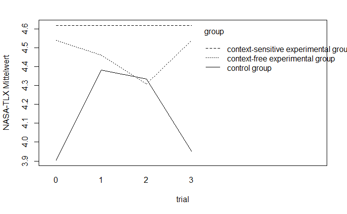

```r
interaction.plot(df_nasa$trial, df_nasa$group, df_nasa$nasa_tlx_performance, xlab = 'trial', ylab = 'NASA-TLX Mittelwert', trace.label = 'group', cex=1.3, pch=1, pt.cex = 1)
```

Check normal distribution assumption by plotting residuals and running Shapiro-Wilk test.

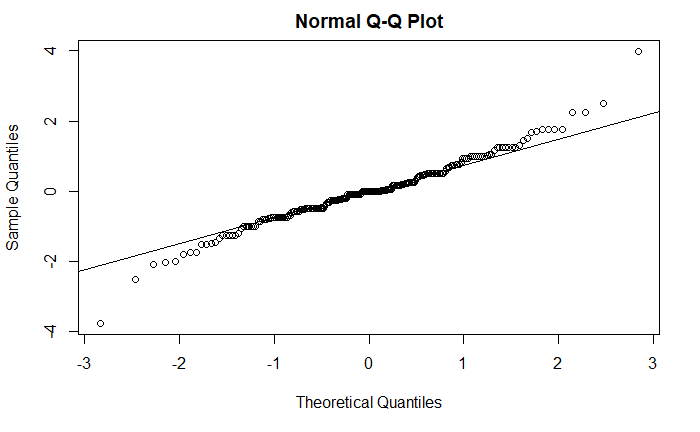

```r
nasa_performance.pr <- proj(nasa_performance_anova$aov)
performance_res <- nasa_performance.pr[[3]][, "Residuals"]
qqnorm(performance_res); qqline(performance_res)
```

```r
# Run Shapiro-Wilk test
shapiro.test(x = performance_res )
```

```
    Shapiro-Wilk normality test

data:  performance_res
W = 0.97202, p-value = 0.0002365
```

Run Levene test for homogeneity of variance across groups

```r
leveneTest(df_nasa$nasa_tlx_performance~df_nasa$group)
```

```
Levene's Test for Homogeneity of Variance (center = median)
       Df F value  Pr(>F)
group   2  4.0559 0.01865 *
      217
---
Signif. codes:  0 ‘***’ 0.001 ‘**’ 0.01 ‘*’ 0.05 ‘.’ 0.1 ‘ ’ 1
```

QQplot of the residuals and the Levene test indicate that the assumptions of normal distribution and variance homogenity are not met, so we compute robust ANOVA.

```r
bwtrim(formula = nasa_tlx_performance ~ group * trial, id = partnr, data = df_nasa)
```

```
Call:
bwtrim(formula = nasa_tlx_performance ~ group * trial, id = partnr,
    data = df_nasa)
```

|  | value | df1 | df2 | p.value |
| --- | --- | --- | --- | --- |
| group | 1.2358 | 2 | 15.8125 | 0.3172 |
| trial | 0.2693 | 3 | 18.4017 | 0.8467 |
| group:trial | 0.7323 | 6 | 15.5143 | 0.6311 |

```
NA
```

```
`fun.y` is deprecated. Use `fun` instead.
```

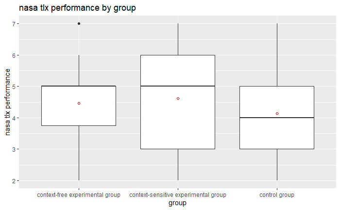

```r
ggplot(df_nasa,aes(x = df_nasa$'group', y=df_nasa$nasa_tlx_performance) ) +
  geom_boxplot() +
  stat_summary(fun.y=mean,shape=1,col='red',geom='point') +
  labs(x="group",
       y = "nasa tlx performance",
       title="nasa tlx performance by group")
```

Plot main effects of trial for subscales

```r
#detach(package:rstatix)
#detach(package:ggpubr)
# frustration
df_nasa %>%
  group_by(trial) %>%
  summarise(nasa_groups = mean(nasa_tlx_frustration),
            nasa_sem = (sd(nasa_tlx_frustration))/sqrt(length(nasa_tlx_frustration))) -> nasa_f
plot_f <- nasa_f %>%
  ggplot() +
  theme_classic() +
  aes(x = trial, y = nasa_groups) +
  geom_line(group = 1) +
  geom_point() +
  geom_linerange(aes(x = trial, ymin = nasa_groups - nasa_sem, ymax = nasa_groups + nasa_sem), size = .3) +
  labs(title = "Frustration per trial", y = "Frustration scores") +
  scale_y_continuous(limits = c(0,7))
# physical demand
df_nasa %>%
   group_by(trial) %>%
  summarise(nasa_groups = mean(nasa_tlx_physical_demand),
            nasa_sem = (sd(nasa_tlx_physical_demand))/sqrt(length(nasa_tlx_physical_demand))) -> nasa_pd
plot_pd <- nasa_pd %>%
  ggplot() +
  theme_classic() +
  aes(x = trial, y = nasa_groups) +
  geom_line(group = 1) +
  geom_point() +
  geom_linerange(aes(x = trial, ymin = nasa_groups - nasa_sem, ymax = nasa_groups + nasa_sem), size = .3) +
  labs(title = "Physical demand per trial", y = "Physical demand scores") +
  scale_y_continuous(limits = c(0,7))
# time
df_nasa %>%
   group_by(trial) %>%
  summarise(nasa_groups = mean(nasa_tlx_time),
            nasa_sem = (sd(nasa_tlx_time))/sqrt(length(nasa_tlx_time))) -> nasa_t
plot_t <- nasa_t %>%
  ggplot() +
  theme_classic() +
  aes(x = trial, y = nasa_groups) +
  geom_line(group = 1) +
  geom_point() +
  geom_linerange(aes(x = trial, ymin = nasa_groups - nasa_sem, ymax = nasa_groups + nasa_sem), size = .3) +
  labs(title = "Time per trial", y = "Time scores") +
  scale_y_continuous(limits = c(0,7))
```

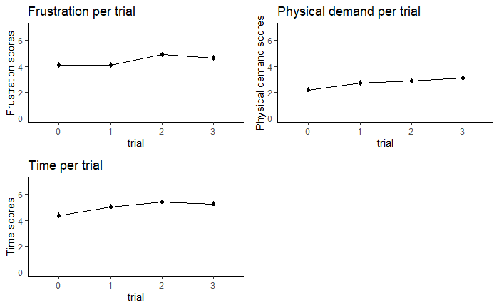